# Bayesian Updating Tutorial with Badenhorst et al. (2023) data set

Tara Lind

## Badenhorst et al. (2023) paper

In the original Badenhorst et al. (2023) study, the primary aim was to compare basal CRP levels between two groups of female athletes — 8 using the oral contraceptive pill (OCP) and 8 who were eumenorrheic (natural menstrual cycle). Each participant was tested on four different days throughout the menstrual or pill cycle.

The main conclusion of this paper was the effect of group (p<0.01), with OCP users consistently exhibiting higher CRP levels than eumenorrheic participants, regardless of the day of testing. Generalised linear mixed models with a Gamma distribution and log link function were used to conduct this analysis. Models were fit with fixed effects for menstrual cycle day and group (OCP users and non-OCP users) and a random intercept per participant.

## Bayesian Analysis

The goal of this analysis is to replicate and quantify this finding using a Bayesian framework. We will compare two models: - Model 1: includes both group and day as predictors - Model 2: includes only day (i.e. no group effect)

This allows us to ask: how much more likely is the data under the model that assumes group differences, versus one that does not?

We are not interested in modelling the interaction or temporal trends at this point, or other other blood markers in the data set. Instead, our focus is to isolate and evaluate the evidence for a group difference.

### Load packages

```r
library(readxl)
library(brms)
library(bridgesampling)
library(tidyverse)
library(lme4)
library(ggResidpanel)
library(car)
library(tidybayes)
library(posterior)
library(kableExtra)
```

### Data

```r
# load in the data
data.long.all <- read_excel("Badenhorst_2023_Dataset.xlsx", sheet = "Data")

# convert ID, day and group into factors
data.long.all$ID <- factor(data.long.all$ID)
data.long.all$DAY <- factor(data.long.all$DAY)
data.long.all$GROUP <- factor(data.long.all$GROUP,
                          labels=c("Natural", "OCP"))
```

Data was retrieved from https://github.com/AndyGovus23/Badenhorst-et-al.-2023-_Iron_Sex_Hormones. The data is already in long format, as it contains one observation (one participant at one time point) per row. The variables we will be using include a participant identifier (ID), C-reactive protein level (CRP), day of testing (DAY), and a group variable indicating whether that participant is an OCP user or natural (GROUP).

### Fitting Bayesian models

We will fit Bayesian hierarchical (mixed-effects) models using the function brm() from the brms package.

```r
# model 1 - day and group as predictors
model_with_group <- brm(
  CRP ~ DAY + GROUP + (1 | ID),
  data = data.long.all,
  family = Gamma(link = "log"),
  chains = 4, cores = 4, iter = 4000,
  control = list(adapt_delta = 0.95),
  save_pars = save_pars(all = TRUE)
)

# model 2 - day as the only predictor
model_without_group <- brm(
  CRP ~ DAY + (1 | ID),
  data = data.long.all,
  family = Gamma(link = "log"),
  chains = 4, cores = 4, iter = 4000,
  control = list(adapt_delta = 0.95),
  save_pars = save_pars(all = TRUE)
)
```

- The first argument specifies the model formula. CRP is the response variable. DAY and GROUP are included as fixed effects, and (1 | ID) adds a random intercept for each participant. This accounts for the repeated measures structure, recognising that multiple observations from the same participant are not independent.
- Badenhorst et al. (2023) note that CRP is non-normally distributed. Given that CRP values are strictly positive and right-skewed, we use a Gamma distribution with a log link function: family = Gamma(link = “log”).
- MCMC settings:
- chains = 4: Run 4 independent Markov Chain Monte Carlo (MCMC) chains.
- cores = 4: Use 4 CPU cores to run the chains in parallel.
- iter = 4000: Each chain runs for 4000 iterations, resulting in 16,000 draws (with half typically used as warm-up). These settings help ensure stable and reliable posterior estimates.
- control = list(adapt_delta = 0.95): Raises the target acceptance rate of the NUTS sampler to reduce the risk of divergent transitions, which can occur in more complex or non-linear models (especially with skewed distributions like Gamma).
- save_pars = save_pars(all = TRUE): Saves all posterior samples and internal model objects. This is necessary for computing Bayes factors later.

The first model (model_with_group) assesses whether CRP levels differ between the two groups (OCP vs eumenorrheic), after accounting for the effect of day and individual variation. The second model (model_without_group) removes GROUP from the formula. It assumes the mean CRP levels are the same across groups, after controlling for day and participant.

#### Priors

In this analysis, we did not manually specify priors, so brms applied its default weakly informative priors. These are designed to support convergence and regularise parameter estimation, particularly useful when sample sizes are modest or the model structure is complex.

### Comparing models

The Bayes Factor quantifies how much more likely the data is under one model compared to the other:

We can compute the Bayes Factor using the bayes_factor() function from the brms package, which implements bridge sampling to estimate marginal likelihoods.

```r
bf_result <- bayes_factor(model_with_group, model_without_group)
```

```r
print(bf_result)
```

```
## Estimated Bayes factor in favor of model_with_group over model_without_group: 523.76610
```

This result means that the model that includes group is over 500 more likely than the model without group, given the observed data. This constitutes very strong evidence in favour of the hypothesis that CRP levels differ between OCP users and non-OCP users, even after controlling for measurement day and individual participant variability.

Conventionally, Bayes Factors are interpreted with the following framework:

```r
bf_table <- data.frame(
  `Bayes Factor` = c("1–3", "3–10", "10–30", "30–100", ">100"),
  `Evidence Strength` = c("Anecdotal", "Moderate", "Strong", "Very strong", "Extreme")
)
kable(bf_table, caption = "Interpretation of Bayes Factors (Stefan et al. 2019)")
```

[output not shown]

To better understand the magnitude and uncertainty of the group effect on CRP, we can visualise the posterior distribution of the model parameter for the group variable. The posterior distribution reflects our updated beliefs, after seeing the data, about how much higher (or lower) CRP is in OCP users relative to natural athletes.

Specifically, we exponentiate the posterior samples of the coefficient for group, which gives us the multiplicative effect of being in the OCP group relative to the natural group.

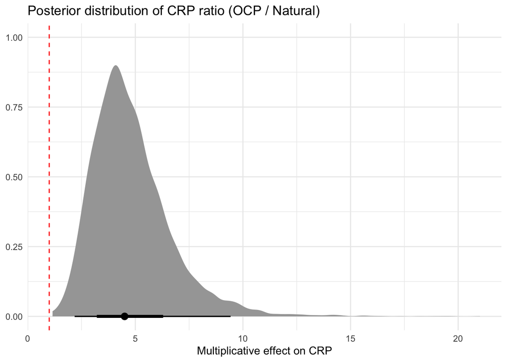

```r
as_draws_df(model_with_group) %>%
  mutate(CRP_ratio = exp(b_GROUPOCP)) %>%
  ggplot(aes(x = CRP_ratio)) +
  stat_halfeye(.width = c(0.66, 0.95)) +
  geom_vline(xintercept = 1, linetype = "dashed",
             colour = "red") + # no difference reference line
  labs(
    title = "Posterior distribution of CRP ratio (OCP / Natural)",
    x = "Multiplicative effect on CRP", y = NULL
  ) +
  theme_minimal()
```

The shaded area in this plot indicates the posterior distribution. The thicker bar along the x-axis is the 66% credible interval, and the thinner bar is the 95% credible interval.

The 95% credible interval lies entirely above 1, indicating strong evidence that CRP levels are higher in the OCP group. While the posterior density tapers near 1, the probability that the true effect is null (i.e., no difference) is extremely low.

The median of the posterior distribution for the CRP ratio is around 4.5, indicating that the CRP levels in the OCP group are estimated to be approximately four and a half times higher than those in the natural (eumenorrheic) group.

This Bayesian approach allows us to move beyond the binary threshold logic of traditional p-values (e.g., p < 0.01). While Badenhorst et al. (2023) reported a statistically significant group difference, the Bayes Factor offers a clear, interpretable measure of evidence strength. Rather than simply saying the result is “significant,” we can now quantify how much more likely the data are under the model that includes the group effect.

## Bayesian Updating

Another strength of the Bayesian approach is the ability to accumulate evidence as new data is added. Unlike traditional frequentist methods, which often require a fixed sample size and a single hypothesis test, Bayesian methods allow us to continuously update our beliefs and quantify evidence at each stage of data collection.

To illustrate this, we will now simulate the process of iteratively collecting data from participants from each group and updating the Bayes Factor.

```r
set.seed(123) # for reproducability

# Split participants into groups and put them into a random order
natural_ids <- sample(unique(data.long.all$ID[data.long.all$GROUP == "Natural"]))
ocp_ids     <- sample(unique(data.long.all$ID[data.long.all$GROUP == "OCP"]))

max_n <- min(length(natural_ids), length(ocp_ids))

# Initial data: 1 participant from each group
initial_ids <- c(natural_ids[1], ocp_ids[1])
initial_data <- data.long.all %>%
  filter(ID %in% initial_ids)

# Fit initial models

# model with group
full <- brm(
  formula = CRP ~ DAY + GROUP + (1 | ID),
  data = initial_data,
  family = Gamma(link = "log"),
  chains = 2, iter = 2000, refresh = 0,
  save_pars = save_pars(all = TRUE),
  silent = TRUE
)

# model without group
reduced <- brm(
  formula = CRP ~ DAY + (1 | ID),
  data = initial_data,
  family = Gamma(link = "log"),
  chains = 2, iter = 2000, refresh = 0,
  save_pars = save_pars(all = TRUE),
  silent = TRUE
)

# Storage for BF results
bf_values <- numeric()
bf_values[1] <- bayes_factor(full, reduced)$bf

# Iteratively update both models
for (i in 2:max_n) {
  message("Running iteration: ", i, " (", 2*i, " total participants)")

  # Add one new participant from each group
  selected_ids <- c(natural_ids[1:i], ocp_ids[1:i])
  new_data <- data.long.all %>%
    filter(ID %in% selected_ids)

  # Use update() to avoid recompilation
  full <- update(full, newdata = new_data, recompile = FALSE, refresh = 0, silent = TRUE)
  reduced <- update(reduced, newdata = new_data, recompile = FALSE, refresh = 0, silent = TRUE)

  # Calculate Bayes Factor
  bf_values[i] <- bayes_factor(full, reduced)$bf
}

# Compile results for plotting
bf_df <- tibble(
  total_participants = 2 * (1:max_n),
  bayes_factor = bf_values
)
```

In this code, we begin by fitting two initial models using data from the first participant in each group. At each subsequent iteration, we incrementally add one participant from each group and use the update() function to refit the models on the expanded dataset without recompiling the Stan code. We then compute the Bayes Factor comparing the full model (with GROUP) to the reduced model (without GROUP), and store these values. Finally, we plot how the Bayes Factor evolves as the total number of participants increases.

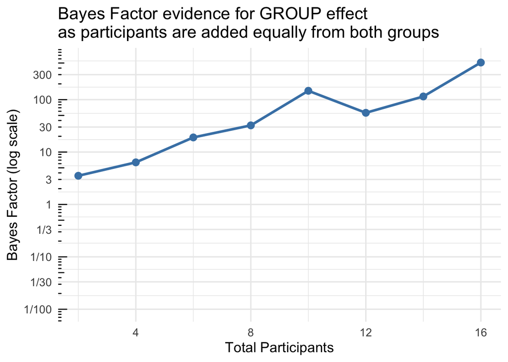

```r
# Plotting

# Making the y-axis have interpretable/meaningful ticks
breaks_vals <- c(1/100, 1/30, 1/10, 1/3, 1, 3, 10, 30, 100, 300)
fraction_labels <- c("1/100", "1/30", "1/10", "1/3", "1", "3", "10", "30", "100", "300")

ggplot(bf_df, aes(x = total_participants, y = bayes_factor)) +
  geom_line(color = "steelblue", size = 1.2) +
  geom_point(color = "steelblue", size = 3) +
  scale_y_log10(
    breaks = breaks_vals,
    labels = fraction_labels,
    limits = c(0.01, max(bf_df$bayes_factor) * 1.1)
  ) +
  labs(
    title = "Bayes Factor evidence for GROUP effect\nas participants are added equally from both groups",
    x = "Total Participants",
    y = "Bayes Factor (log scale)"
  ) +
  annotation_logticks(sides = "l") +
  theme_minimal(base_size = 14)
```

### Validating with multiple random orderings

To ensure that our results are not dependent on the particular order in which participants were sampled and to help validate the robustness of this analysis, here we repeat the simulation described above across five independent random orderings.

```r
set.seed(123) # for reproducability

n_runs <- 5  # Number of random orderings to do
bf_all <- list()  # To store all runs results

for (run in 1:n_runs) {
  message("Starting run ", run)

  # Shuffle IDs independently each run
  natural_ids <- sample(unique(data.long.all$ID[data.long.all$GROUP == "Natural"]))
  ocp_ids     <- sample(unique(data.long.all$ID[data.long.all$GROUP == "OCP"]))

  max_n <- min(length(natural_ids), length(ocp_ids))
  bf_values <- numeric(max_n)

  for (i in 1:max_n) {
    message("Run ", run, " iteration: ", i, " (", 2*i, " total participants)")

    selected_ids <- c(natural_ids[1:i], ocp_ids[1:i])
    subset_data <- data.long.all %>% filter(ID %in% selected_ids)

    full <- brm(
      formula = CRP ~ DAY + GROUP + (1 | ID),
      data = subset_data,
      family = Gamma(link = "log"),
      chains = 2, iter = 2000, refresh = 0,
      save_pars = save_pars(all = TRUE), silent = TRUE
    )

    reduced <- brm(
      formula = CRP ~ DAY + (1 | ID),
      data = subset_data,
      family = Gamma(link = "log"),
      chains = 2, iter = 2000, refresh = 0,
      save_pars = save_pars(all = TRUE), silent = TRUE
    )

    bf_values[i] <- bayes_factor(full, reduced)$bf
  }

  bf_all[[run]] <- tibble(
    run = paste0("Run ", run),
    total_participants = 2 * (1:max_n),
    bayes_factor = bf_values
  )
}
```

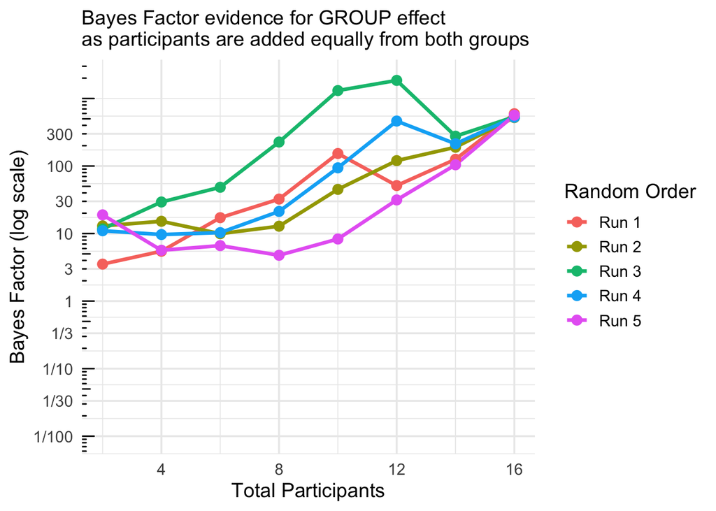

```r
# Combine all runs into one dataframe
bf_df_all <- bind_rows(bf_all)

# Making the y-axis have interpretable/meaningful ticks
breaks_vals <- c(1/100, 1/30, 1/10, 1/3, 1, 3, 10, 30, 100, 300)
fraction_labels <- c("1/100", "1/30", "1/10", "1/3", "1", "3", "10", "30", "100", "300")

# Plot showing the multiple runs, color by run
ggplot(bf_df_all, aes(x = total_participants, y = bayes_factor, color = run)) +
  geom_line(size = 1.2) +
  geom_point(size = 3) +
  scale_y_log10(
    breaks = breaks_vals,
    labels = fraction_labels,
    limits = c(0.01, max(bf_df_all$bayes_factor) * 1.1)
  ) +
  labs(
    subtitle = "Bayes Factor evidence for GROUP effect\nas participants are added equally from both groups",
    x = "Total Participants",
    y = "Bayes Factor (log scale)",
    color = "Random Order"
  ) +
  annotation_logticks(sides = "l") +
  theme_minimal(base_size = 14)
```

## Conclusion

Bayesian updating allows us to quantify evidence dynamically, rather than waiting for the entire study to complete. This approach can therefore support data efficiency, save resources and time, and allow for dynamic decision-making. Bayesian updating thus offers a powerful framework for real-time evidence assessment and efficient study design.

## References

Badenhorst, C. E., Govus, A. D., & Mündel, T. (2023). Does chronic oral contraceptive use detrimentally affect C-reactive protein or iron status for endurance-trained women? Physiological Reports, 11(14), e15777. https://doi.org/https://doi.org/10.14814/phy2.15777

Stefan, A. M., Gronau, Q. F., Schönbrodt, F. D., & Wagenmakers, E.-J. (2019). A tutorial on Bayes Factor Design Analysis using an informed prior. Behavior Research Methods, 51(3), 1042-1058. https://doi.org/10.3758/s13428-018-01189-8